# STAT PR2

9/1/2015

### ISCAM Investigation 1.2

**Question c.** How many subjects participated in your study? What proportion of the respondents agreed that the face with the goatee was Tim? Does this appear to be an “overwhelming majority” to you?

*n = 22 participated*  
*$\frac{16}{22} \approx$ 0.7272727 is the proportion who selected the goatee man as Tim.*  
*I would not call the proportion an overwhelming majority, since it was only 72% of the participants selected the man with the goatee as Tim. Nonetheless, I would say the proportion is a majority.*

**Question d.** Produce a bar graph of the results. Make sure the axes are well-labeled. Can we conclude from this graph that people use facial prototyping? Explain.

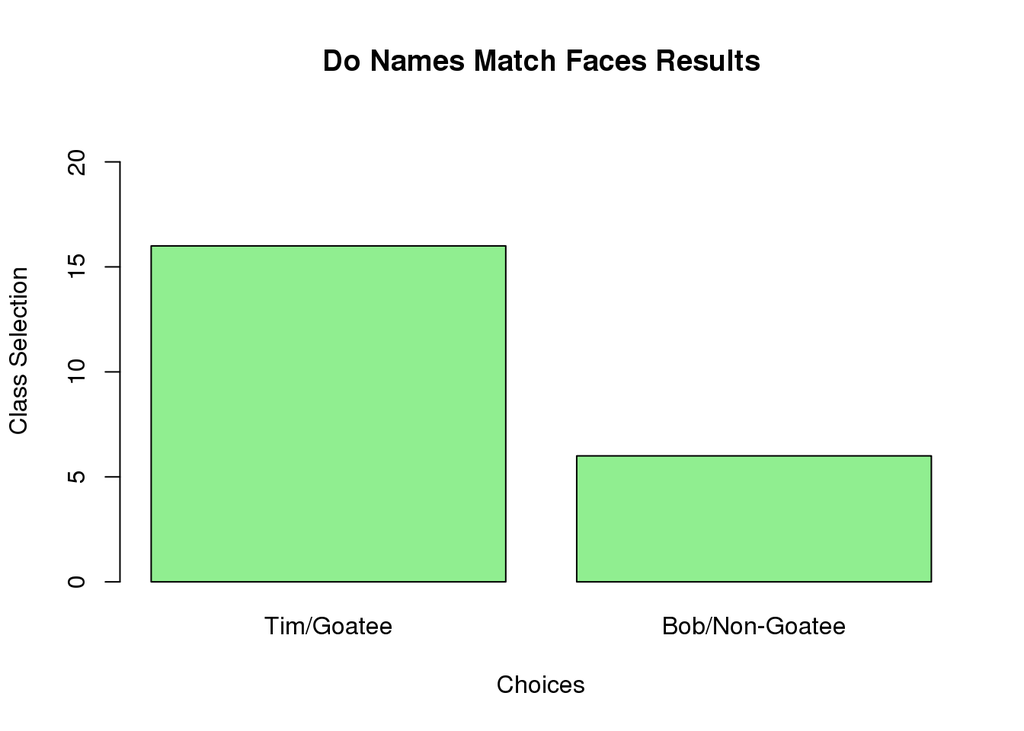

```r
#This code is used to create a bar graph, where 16 students chose goatee man and 6 students chose non-goatee man.
H <- c(16,6)
barplot(H, main="Do Names Match Faces Results", xlab="Choices", ylab="Class Selection", names.arg=c("Tim/Goatee","Bob/Non-Goatee"),
border="black",ylim = c(0, 22),col= "light green")
```

*We can not conclude that people use facial prototyping from the graph, because the graph only represents the number of people who selected Tim or Bob.*

**Question k.** Find and report the p-value from your technology (including appropriate notation for the event you used).

```r
#This code is used to create four different methods to compute the p-value.
a <-choose(22,16)*(.5)^16*(.5)^6
b <-choose(22,17)*(.5)^17*(.5)^5
c <-choose(22,18)*(.5)^18*(.5)^4
d <-choose(22,19)*(.5)^19*(.5)^3
e <-choose(22,20)*(.5)^20*(.5)^2
f <-choose(22,21)*(.5)^21*(.5)^1
g <-choose(22,22)*(.5)^22*(.5)^0
sum(a,b,c,d,e,f,g)
```

```
## [1] 0.0262394
```

```r
1-pbinom(15,22,.5)
```

```
## [1] 0.0262394
```

```r
sum(dbinom(16:22,22,.5))
```

```
## [1] 0.0262394
```

```r
1-sum(dbinom(0:15,22,.5))
```

```
## [1] 0.0262394
```

*The p-value for 16 or more people select the goatee man out of 22 people is 0.0262*

**Question l.** Write a one-sentence *interpretation* of the p-value that you have calculated. Be sure it is clear what you found the probability of and any assumptions underlying the calculation. [*Hint*: Recall the simulations you performed in the Investigation 1.1.]

*The probability that 16 or more people randomly selected the man with the goatee out of 22 people is 0.0262.*

**Question m.** Would you consider the class results to be *statistically significant*? Explain.

*I believe the class results to be statistically significant, because the smaller the p-value the stronger the evidence is against the null model. Thus, I believe a number such as 0.026 is a small enough to be considered significant.*

**Question n.** Based on your calculations, does your class study provide strong evidence that students are likely to match the name Tim to the face with the goatee more than we would expect if they are just guessing?

*The class study does provide strong evidence, because the p-value is between 0.05 and 0.01*

### ISCAM Investigation 1.3: Heart Transplant Mortality

**Question h.** Open the One Proportion Inference applet and generate 1000 samples from a binomial process with $\pi$=0.15 (under the null model) and n=10. Comment on the shape of the distribution.

```r
#The first part of this code is used to create a random sample to determine the number of people who would live with a benchmark of 15%, and last part of the code is used to create a bar graph with a sample size of 1000.
sample(0:1, 10, replace=TRUE, prob=c(0.85,0.15))
```

```
##  [1] 0 0 0 0 0 0 0 0 0 0
```

```r
heartdata <-rbinom(1000, 10, .15)
sum(heartdata>4)
```

```
## [1] 8
```

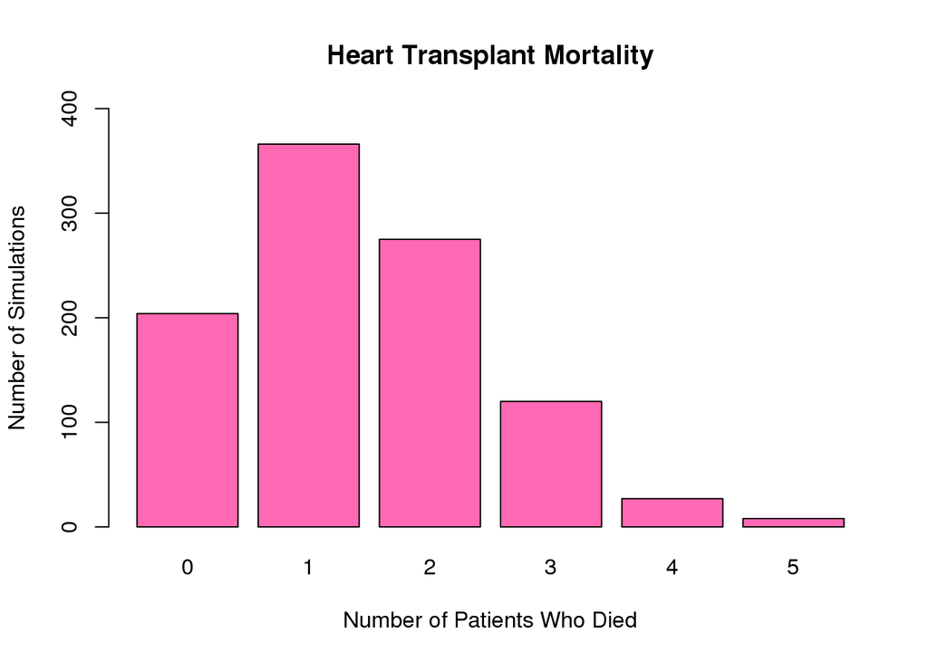

```r
barplot(xtabs(~heartdata), col="hot pink", ylim=c(0,400), main="Heart Transplant Mortality", xlab="Number of Patients Who Died", ylab="Number of Simulations")
```

*The shape of the distribution is skewed right as shown above.*

**Question i.** Estimate the p-value from this null distribution. Clearly explain how you did so.

```r
#This code is used to calculate the number of times 8 or more patients died.
heartdata[heartdata>=8]
```

```
## integer(0)
```

*I believe the p-value from a null distribution is zero provided assistance from the graph and the “simulation” presented above.*

**Question j.** Check the **Exact Binomial** box to have the applet determine the exact p-value. Report and interpret this value below (what is it the probability of?).

```r
#This code is used to create four different methods to compute the p-value.
aa <-choose(10,8)*(.15)^8*(.85)^2
bb <-choose(10,9)*(.15)^9*(.85)^1
cc <-choose(10,10)*(.15)^10*(.85)^0
sum(aa,bb,cc)
```

```
## [1] 8.665133e-06
```

```r
1-pbinom(7,10,.15)
```

```
## [1] 8.665133e-06
```

```r
sum(dbinom(8:10,10,.15))
```

```
## [1] 8.665133e-06
```

```r
1-sum(dbinom(0:7,10,.15))
```

```
## [1] 8.665133e-06
```

*The p-value calculates to 0.0000087, which means that out of 10 people the probability of 8 or more people dying is a very rare occurance.*

**Question l.** Suppose that we had focused on survival for 30 days rather than death within 30 days as a “success” in this study. Describe how the hypotheses would change and how the calculation of the binomial p-value would change. Then go ahead and calculate the exact binomial p-value with this set-up. How does its value compare to your answer in (j)? How (if at all) does your conclusion change?

*Orginally, the null hypothesis was $H_{o}$: $\pi$= 0.15. In order to calculate the p-value, the probability of 8 or more deaths out of the 10 heart transplant patients was determined. The new null hypothesis is $H_{o}$: $\pi$= 0.85. In order to calculate the p-value, the probability of 2 or less survivors out of the 10 heart transplant patients was determined. The p-value calculation is below:*

```r
#This code is used to create four different methods to compute the p-value.
pbinom(2,10,.85)
```

```
## [1] 8.665133e-06
```

*The p-value remains the same as 0.0000087. Therefore, my conclusion remains the same as well since we originally wanted to determine the probability of 8 or more heart transplant patients die within 30 days, which is a rare occurance. Then the probability of 2 or less heart transplant patients live within 30 days is determined, which is also a rare occurance. By determining a rare occurance for both scenarios especially with the exact p-value, it provided us with the same conclusion - the probability of either event occuring is very rare.*

**Question m.** Following up on the suspicion that the sample of size 10 aroused, these researchers proceeded to gather data on the previous 361 patients who received a heart transplant at this hospital dating back to 1986. They found 71 deaths.

Calculate the sample proportion for these data: *$\frac{71}{361}$ = 0.19667*

**Predict whether this is more or less convincing evidence that this hospital’s death rate exceeds 0.15? Explain your reasoning.**  
**This is more convincing evidence, because the proportion of deaths is greater than reasonable death benchmark of 15%.**

Use the One Proportion Inference applet to determine (approximately with simulation, and exactly with the binomial distribution) the probability of finding at least 71 deaths in a sample of 361 if $\pi$ = 0.15.

```r
#This code is used to create a random sample with a sample size 1000.
sample(0:1, 361, replace=TRUE, prob=c(0.15,0.85))
```

```
##   [1] 1 1 1 1 0 0 1 1 1 1 1 1 1 1 1 0 0 0 1 0 1 1 1 1 0 0 1 1 1 1 1 0 1 1 1
##  [36] 0 1 0 1 1 1 1 1 0 1 1 1 1 0 1 1 1 1 1 1 0 1 1 1 1 1 1 1 1 1 1 1 1 1 1
##  [71] 1 1 1 1 1 0 1 1 0 1 0 1 1 1 0 1 1 0 1 1 0 1 1 1 1 1 1 1 1 1 1 1 1 1 1
## [106] 1 0 1 1 1 1 0 1 1 1 1 1 1 1 1 1 1 1 1 1 1 1 1 1 1 1 1 1 0 1 1 1 1 0 1
## [141] 1 1 0 1 0 1 1 1 1 1 1 1 1 1 1 0 1 1 1 1 1 0 1 0 1 1 1 1 1 1 1 1 1 1 0
## [176] 1 1 1 1 1 1 1 1 1 1 1 1 1 1 1 1 1 1 1 1 1 1 1 1 1 1 0 1 1 0 1 1 1 1 1
## [211] 0 1 1 1 1 1 1 1 1 0 1 0 0 1 1 1 1 0 1 1 1 1 1 1 0 1 1 1 0 1 1 1 1 1 1
## [246] 1 1 0 1 0 1 1 1 1 0 1 1 0 1 1 1 0 1 1 1 1 1 0 1 0 1 1 1 1 1 1 0 1 0 0
## [281] 1 1 0 0 1 1 1 1 1 1 1 1 1 1 1 1 0 1 1 1 0 1 1 1 1 1 1 1 0 1 1 1 1 1 1
## [316] 1 1 1 0 1 0 0 1 1 1 0 1 1 1 1 1 1 1 1 0 1 1 1 1 1 1 0 0 1 1 1 0 1 0 1
## [351] 1 1 1 1 1 1 1 1 1 1 0
```

```r
heartdata <-rbinom(1000, 361, .15)
hd <-sum(heartdata>=71)
```

*The probability of 71 or more deaths occuring from a sample size of 361 with benchmark of 15% is $\frac{9}{1000} \approx$ 0.009.*

### RR Chapter 3 Summary

*Chapter three in Reproducible Research with R and RStudio begins by breaking down RStudio for the people who has ever used RStudio before. It explains the basics of using R such as objects, functions, commands, and history, and provided examples of how to type any information. Next, there was a picture of RStudio, which provided guidance as the chapter explained the lay out and the panes. Finally, knitr and rmarkdown uses and how to use them was explained, along with code chunks and knitr package. I thought this chapter was the best thus far, because it provided tips and helped explained what I have been confused about such as how to type codes, and what knitr and rmarkdown does.*